# Showwcase_analysis

```r
library(readr)
library(readxl)
library(ggplot2)
library(plyr)
library(dplyr)
library(describer)
library(forcats)
library(lubridate)
library(corrplot)
showwcase_sessions <- read_csv("C:/Users/prath/Documents/Crowd Doing/Showwcase files/showwcase_sessions.csv")
```

## Descriptive analysis

```r
head(showwcase_sessions)
```

```
## # A tibble: 6 x 14
##   session_id customer_id login_date projects_added likes_given comment_given
##        <dbl>       <dbl> <chr>      <lgl>          <lgl>       <lgl>
## 1     272981       10246 10/21/2019 TRUE           TRUE        FALSE
## 2     215590       10246 10/21/2019 TRUE           TRUE        FALSE
## 3     112122       10246 10/15/2019 FALSE          TRUE        FALSE
## 4     133256       10246 10/6/2019  TRUE           TRUE        TRUE
## 5     922001       12407 10/30/2019 TRUE           FALSE       TRUE
## 6     350315       12407 10/26/2019 TRUE           TRUE        TRUE
## # ... with 8 more variables: inactive_status <lgl>, bug_occured <lgl>,
## #   session_projects_added <dbl>, session_likes_given <dbl>,
## #   session_comments_given <dbl>, inactive_duration <dbl>,
## #   bugs_in_session <dbl>, session_duration <dbl>
```

```r
str(showwcase_sessions)
```

```
## tibble [300 x 14] (S3: spec_tbl_df/tbl_df/tbl/data.frame)
##  $ session_id            : num [1:300] 272981 215590 112122 133256 922001 ...
##  $ customer_id           : num [1:300] 10246 10246 10246 10246 12407 ...
##  $ login_date            : chr [1:300] "10/21/2019" "10/21/2019" "10/15/2019" "10/6/2019" ...
##  $ projects_added        : logi [1:300] TRUE TRUE FALSE TRUE TRUE TRUE ...
##  $ likes_given           : logi [1:300] TRUE TRUE TRUE TRUE FALSE TRUE ...
##  $ comment_given         : logi [1:300] FALSE FALSE FALSE TRUE TRUE TRUE ...
##  $ inactive_status       : logi [1:300] TRUE FALSE FALSE TRUE FALSE TRUE ...
##  $ bug_occured           : logi [1:300] TRUE TRUE FALSE TRUE FALSE TRUE ...
##  $ session_projects_added: num [1:300] 3 2 0 3 5 2 0 1 3 1 ...
##  $ session_likes_given   : num [1:300] 7 16 14 16 0 3 16 0 15 26 ...
##  $ session_comments_given: num [1:300] 0 0 0 3 5 2 3 5 2 2 ...
##  $ inactive_duration     : num [1:300] 2120 0 0 315 0 ...
##  $ bugs_in_session       : num [1:300] 2 5 0 2 0 3 0 3 0 0 ...
##  $ session_duration      : num [1:300] 53 346 2075 389 1329 ...
##  - attr(*, "spec")=
##   .. cols(
##   ..   session_id = col_double(),
##   ..   customer_id = col_double(),
##   ..   login_date = col_character(),
##   ..   projects_added = col_logical(),
##   ..   likes_given = col_logical(),
##   ..   comment_given = col_logical(),
##   ..   inactive_status = col_logical(),
##   ..   bug_occured = col_logical(),
##   ..   session_projects_added = col_double(),
##   ..   session_likes_given = col_double(),
##   ..   session_comments_given = col_double(),
##   ..   inactive_duration = col_double(),
##   ..   bugs_in_session = col_double(),
##   ..   session_duration = col_double()
##   .. )
```

```r
describe(showwcase_sessions)
```

```
##              .column_name .column_class .column_type .count_elements
## 1              session_id       numeric       double             300
## 2             customer_id       numeric       double             300
## 3              login_date     character    character             300
## 4          projects_added       logical      logical             300
## 5             likes_given       logical      logical             300
## 6           comment_given       logical      logical             300
## 7         inactive_status       logical      logical             300
## 8             bug_occured       logical      logical             300
## 9  session_projects_added       numeric       double             300
## 10    session_likes_given       numeric       double             300
## 11 session_comments_given       numeric       double             300
## 12      inactive_duration       numeric       double             300
## 13        bugs_in_session       numeric       double             300
## 14       session_duration       numeric       double             300
```

[output cut: 30 more lines]

```r
summary(showwcase_sessions)
```

```
##    session_id      customer_id     login_date        projects_added
##  Min.   : 22885   Min.   :10246   Length:300         Mode :logical
##  1st Qu.:308358   1st Qu.:23571   Class :character   FALSE:73
##  Median :553675   Median :38967   Mode  :character   TRUE :227
##  Mean   :530643   Mean   :44957
##  3rd Qu.:804120   3rd Qu.:73245
##  Max.   :999480   Max.   :98653
##
##  likes_given     comment_given   inactive_status bug_occured
##  Mode :logical   Mode :logical   Mode :logical   Mode :logical
##  FALSE:87        FALSE:75        FALSE:128       FALSE:184
##  TRUE :213       TRUE :225       TRUE :172       TRUE :116
##
##
##
##
##  session_projects_added session_likes_given session_comments_given
##  Min.   :0.00           Min.   : 0.00       Min.   : 0.000
##  1st Qu.:1.00           1st Qu.: 0.00       1st Qu.: 0.750
##  Median :2.00           Median : 9.00       Median : 2.000
##  Mean   :1.62           Mean   :10.46       Mean   : 2.407
##  3rd Qu.:3.00           3rd Qu.:19.00       3rd Qu.: 4.000
##  Max.   :9.00           Max.   :27.00       Max.   :21.000
##                         NA's   :1
##  inactive_duration bugs_in_session session_duration
##  Min.   :   0.0    Min.   :0.000   Min.   :  10.0
##  1st Qu.:   0.0    1st Qu.:0.000   1st Qu.: 611.2
##  Median : 313.5    Median :0.000   Median :1152.0
##  Mean   : 732.9    Mean   :1.233   Mean   :1186.8
##  3rd Qu.:1524.8    3rd Qu.:2.250   3rd Qu.:1778.0
##  Max.   :2480.0    Max.   :5.000   Max.   :2395.0
##
```

### Converting boolean values in project added, likes given, inactive status, and bug occured to 0 or 1 in order to analyze the data.

“1” = “TRUE” “0” = “FALSE”

```r
showwcase_sessions$ID <- seq.int(nrow(showwcase_sessions))
## Recoding showwcase_sessions$projects_added into showwcase_sessions$projects_added_rec
showwcase_sessions$projects_added <- as.factor(showwcase_sessions$projects_added)
showwcase_sessions$projects_added <- fct_recode(showwcase_sessions$projects_added,
  "1" = "TRUE",
  "0" = "FALSE")

showwcase_sessions$likes_given <- as.factor(showwcase_sessions$likes_given)
showwcase_sessions$likes_given <- fct_recode(showwcase_sessions$likes_given,
  "1" = "TRUE",
  "0" = "FALSE")

showwcase_sessions$comment_given <- as.factor(showwcase_sessions$comment_given)
showwcase_sessions$comment_given <- fct_recode(showwcase_sessions$comment_given,
  "1" = "TRUE",
  "0" = "FALSE")

showwcase_sessions$inactive_status <- as.factor(showwcase_sessions$inactive_status)
showwcase_sessions$inactive_status <- fct_recode(showwcase_sessions$inactive_status,
  "1" = "TRUE",
  "0" = "FALSE")

showwcase_sessions$bug_occured <- as.factor(showwcase_sessions$bug_occured)
showwcase_sessions$bug_occured <- fct_recode(showwcase_sessions$bug_occured,
  "1" = "TRUE",
  "0" = "FALSE")
```

```r
summary(showwcase_sessions)
```

```
##    session_id      customer_id     login_date        projects_added likes_given
##  Min.   : 22885   Min.   :10246   Length:300         0: 73          0: 87
##  1st Qu.:308358   1st Qu.:23571   Class :character   1:227          1:213
##  Median :553675   Median :38967   Mode  :character
##  Mean   :530643   Mean   :44957
##  3rd Qu.:804120   3rd Qu.:73245
##  Max.   :999480   Max.   :98653
##
##  comment_given inactive_status bug_occured session_projects_added
##  0: 75         0:128           0:184       Min.   :0.00
##  1:225         1:172           1:116       1st Qu.:1.00
##                                            Median :2.00
##                                            Mean   :1.62
##                                            3rd Qu.:3.00
##                                            Max.   :9.00
##
##  session_likes_given session_comments_given inactive_duration bugs_in_session
##  Min.   : 0.00       Min.   : 0.000         Min.   :   0.0    Min.   :0.000
##  1st Qu.: 0.00       1st Qu.: 0.750         1st Qu.:   0.0    1st Qu.:0.000
##  Median : 9.00       Median : 2.000         Median : 313.5    Median :0.000
##  Mean   :10.46       Mean   : 2.407         Mean   : 732.9    Mean   :1.233
##  3rd Qu.:19.00       3rd Qu.: 4.000         3rd Qu.:1524.8    3rd Qu.:2.250
##  Max.   :27.00       Max.   :21.000         Max.   :2480.0    Max.   :5.000
##  NA's   :1
##  session_duration       ID
##  Min.   :  10.0   Min.   :  1.00
##  1st Qu.: 611.2   1st Qu.: 75.75
##  Median :1152.0   Median :150.50
##  Mean   :1186.8   Mean   :150.50
##  3rd Qu.:1778.0   3rd Qu.:225.25
##  Max.   :2395.0   Max.   :300.00
##
```

### Extract day and day number from the login date.

```r
showwcase_sessions$login_date<- as.Date(showwcase_sessions$login_date,  "%m/%d/%Y")

showwcase_sessions$Day <- wday(showwcase_sessions$login_date)
showwcase_sessions$Dayofmonth <- weekdays(showwcase_sessions$login_date)
```

## Exploratory data analysis

### User segmentation analysis

#### 1. Analyze how many number of users used projects added, likes given and comment given. Filtering these features as 1. There are 33 users who used all the features of the platform. There are total 48 users.

```r
User_segmentation <- showwcase_sessions %>%
  select(customer_id,projects_added,likes_given,comment_given) %>%
  filter(projects_added == 1 & likes_given == 1 & comment_given == 1) %>%
  group_by(customer_id) %>%
  summarise(customer_id_summary = n()) %>%
  arrange(desc(customer_id_summary))


str(User_segmentation)
```

```
## tibble [33 x 2] (S3: tbl_df/tbl/data.frame)
##  $ customer_id        : num [1:33] 87323 14354 23404 73245 87265 ...
##  $ customer_id_summary: int [1:33] 10 8 8 8 8 7 6 6 6 5 ...
##  - attr(*, "spec")=
##   .. cols(
##   ..   session_id = col_double(),
##   ..   customer_id = col_double(),
##   ..   login_date = col_character(),
##   ..   projects_added = col_logical(),
##   ..   likes_given = col_logical(),
##   ..   comment_given = col_logical(),
##   ..   inactive_status = col_logical(),
##   ..   bug_occured = col_logical(),
##   ..   session_projects_added = col_double(),
##   ..   session_likes_given = col_double(),
##   ..   session_comments_given = col_double(),
##   ..   inactive_duration = col_double(),
##   ..   bugs_in_session = col_double(),
##   ..   session_duration = col_double()
##   .. )
```

##### 2.How many unique users visited in october month

```r
Unique_users <- showwcase_sessions %>%
select(customer_id) %>%
  group_by(customer_id) %>%
  summarise(customer_id_summary = n()) %>%
  arrange(desc(customer_id_summary))
```

##### 3. Analyze which feature has been mostly by the user. The most used feature used by the user is Project added and then comments given. Likes given is comparitively less used than the other two.

Project_Added = 227 Comments_given = 225 Likes_given = 213

```r
Project_added_feature <- showwcase_sessions %>%
  select(customer_id,projects_added) %>%
  filter(projects_added == 1 ) %>%
  group_by(customer_id) %>%
  summarise(customer_id_summary = n()) %>%
  arrange(desc(customer_id_summary)) %>%
  mutate(total = sum(customer_id_summary))

comment_given_feature <- showwcase_sessions %>%
  select(customer_id,comment_given) %>%
  filter(comment_given == 1 ) %>%
  group_by(customer_id) %>%
  summarise(customer_id_summary = n()) %>%
  arrange(desc(customer_id_summary)) %>%
  mutate(total = sum(customer_id_summary))

likes_given_feature <- showwcase_sessions %>%
  select(customer_id,likes_given) %>%
  filter(likes_given == 1 ) %>%
  group_by(customer_id) %>%
  summarise(customer_id_summary = n()) %>%
  arrange(desc(customer_id_summary)) %>%
  mutate(total = sum(customer_id_summary))
```

##### 4. Analyze trends and patterns in the top five users.

```r
User_newsegmentation <- showwcase_sessions %>%
  select(customer_id,projects_added,likes_given,comment_given,session_projects_added,session_likes_given,session_comments_given) %>%
  group_by(customer_id) %>%
  filter(projects_added == 1 & likes_given == 1 & comment_given == 1)


library(data.table)
Session_featues <- data.table(User_newsegmentation)
Session_featues <- Session_featues[,list(projects_added_per_user = sum(session_projects_added), comments_added_per_user = sum(session_comments_given), likes_added_per_user = sum(session_likes_given), freq = .N), by = c("customer_id")]
```

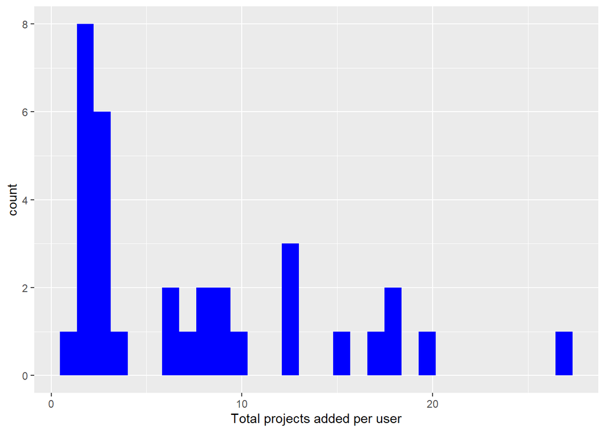

```r
ggplot(Session_featues, aes(x= Session_featues$projects_added_per_user)) + geom_histogram(bins = 30, fill = "blue") + xlab("Total projects added per user")
```

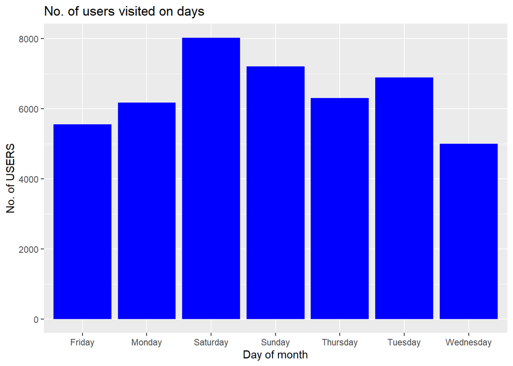

```r
ggplot(showwcase_sessions, aes(x=showwcase_sessions$Dayofmonth,y=showwcase_sessions$ID)) + geom_col(stat = "count", fill = "blue")+ xlab("Day of month") + ylab("No. of USERS") + ggtitle("No. of users visited on days")
```

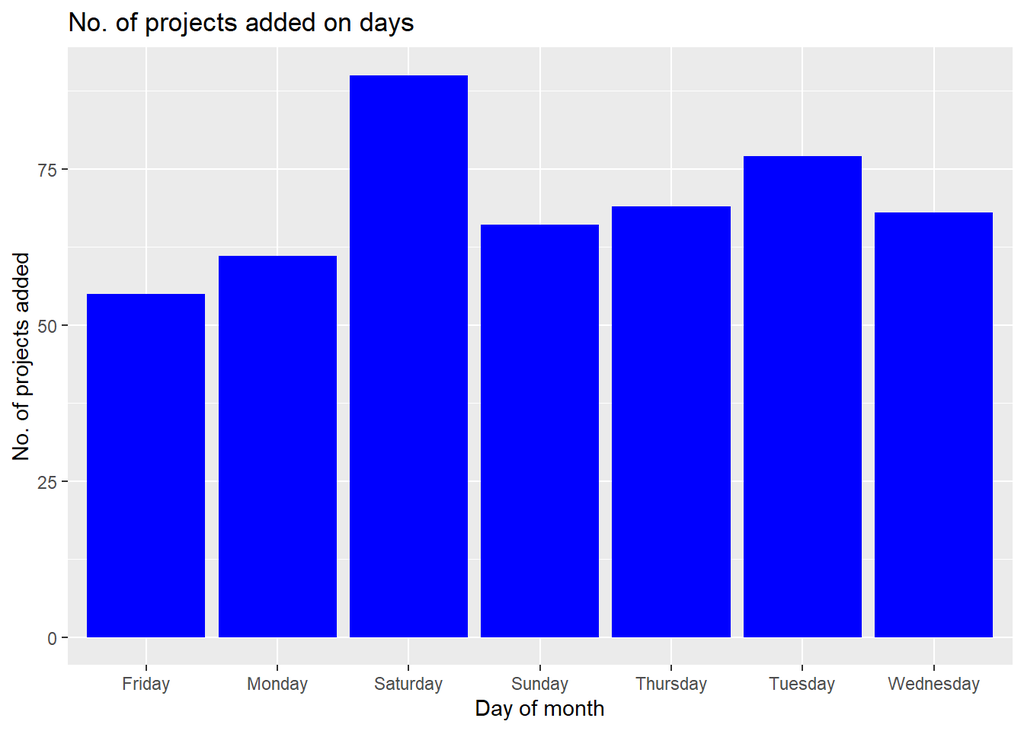

```r
ggplot(showwcase_sessions, aes(x=showwcase_sessions$Dayofmonth,y=showwcase_sessions$session_projects_added)) + geom_col(stat = "count", fill = "blue")+ xlab("Day of month") + ylab("No. of projects added") + ggtitle("No. of projects added on days")
```

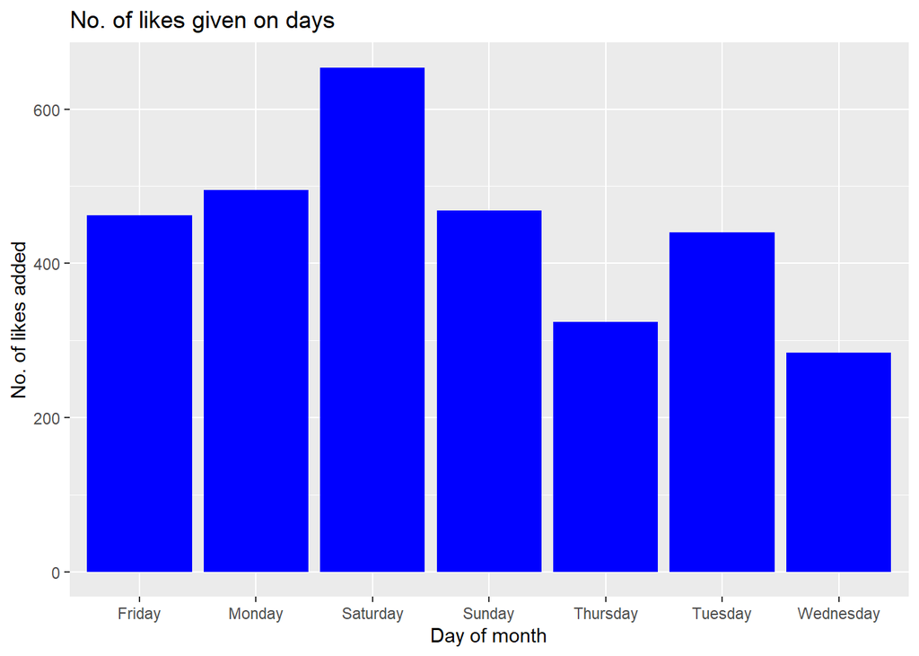

```r
ggplot(showwcase_sessions, aes(x=showwcase_sessions$Dayofmonth,y=showwcase_sessions$session_likes_given)) + geom_col(stat = "count", fill = "blue")+ xlab("Day of month") + ylab("No. of likes added") + ggtitle("No. of likes given on days")
```

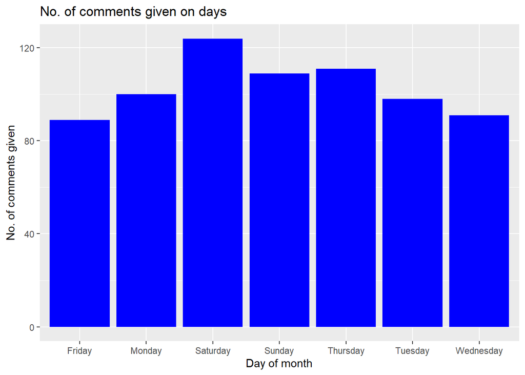

```r
ggplot(showwcase_sessions, aes(x=showwcase_sessions$Dayofmonth,y=showwcase_sessions$session_comments_given)) + geom_col(stat = "count", fill = "blue")+ xlab("Day of month") + ylab("No. of comments given") + ggtitle("No. of comments given on days")
```

#### Most of the features are added on saturday when most of the users are free.

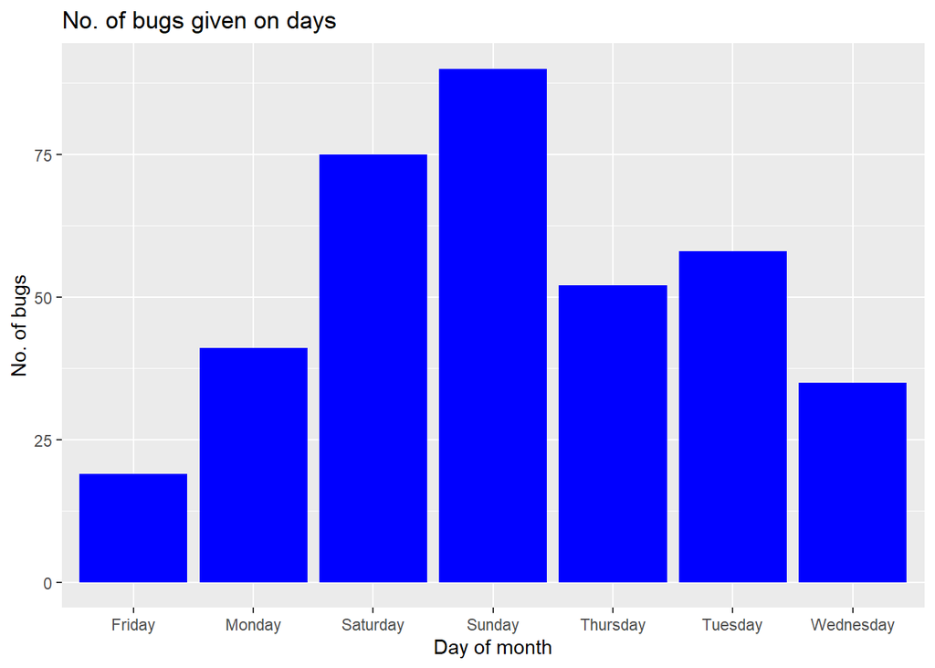

```r
ggplot(showwcase_sessions, aes(x=showwcase_sessions$Dayofmonth,y=showwcase_sessions$bugs_in_session)) + geom_col(stat = "count", fill = "blue")+ xlab("Day of month") + ylab("No. of bugs") + ggtitle("No. of bugs given on days")
```

#### As we can see that most of the number of bugs are reported on saturday and sunday when many people are logging in and using features.

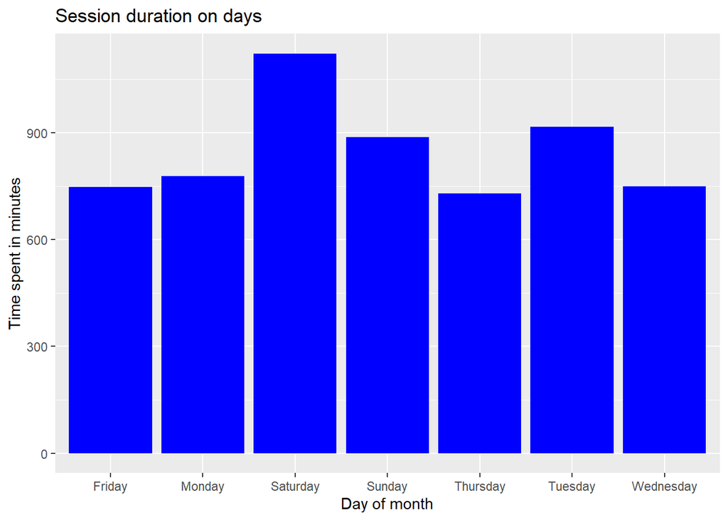

```r
## convert seconds to minutes  for proper analysis

showwcase_sessions$sessionminute <- showwcase_sessions$session_duration / 60
showwcase_sessions$inactiveminute <- showwcase_sessions$inactive_duration / 60

showwcase_sessions$sessionminute <-round(showwcase_sessions$sessionminute, digits=2)
showwcase_sessions$inactiveminute <-round(showwcase_sessions$inactiveminute, digits=2)

ggplot(showwcase_sessions, aes(x=showwcase_sessions$Dayofmonth, y = showwcase_sessions$sessionminute)) + geom_col(stat = "count", fill = "blue")+ xlab("Day of month") + ylab("Time spent in minutes") + ggtitle("Session duration on days")
```

#### Most of the time (in minutes) is spent on Saturday and Tuesday which maybe due to bugs in the system

```r
top_users <- showwcase_sessions %>%
  select(session_projects_added,session_likes_given,session_comments_given,session_duration,customer_id,sessionminute,inactiveminute, Dayofmonth) %>%
  group_by(customer_id, Dayofmonth) %>%
  summarise(total_projects = sum(session_projects_added), total_comments = sum(session_comments_given), total_likes = sum(session_likes_given), total_minutes = sum(sessionminute),total_inactive_minute = sum(inactiveminute)) %>%
  arrange(desc(total_minutes))


top_users %>% top_n(10)  # highest values
```

```
## # A tibble: 169 x 7
## # Groups:   customer_id [48]
##    customer_id Dayofmonth total_projects total_comments total_likes
##          <dbl> <chr>               <dbl>          <dbl>       <dbl>
##  1       40235 Saturday                7              9          38
##  2       87265 Sunday                 10             13          48
##  3       29375 Saturday                4             13          32
##  4       23404 Friday                  2             12          58
##  5       23404 Thursday                5             12          30
##  6       87323 Tuesday                 9              6          15
##  7       29375 Sunday                  2              9          16
##  8       73245 Wednesday               9             12          60
##  9       38459 Monday                  3             13          24
## 10       29375 Tuesday                 3              4          45
## # ... with 159 more rows, and 2 more variables: total_minutes <dbl>,
## #   total_inactive_minute <dbl>
```

#### Export data to csv

```r
write.csv(showwcase_sessions, file = "showwcase_sessions_new.csv")
```

## Machine learning

#### Machine learning for preddicting factors that can affect the session duration. Session duration is a depedent variable and others as independent variable

#### Correlation

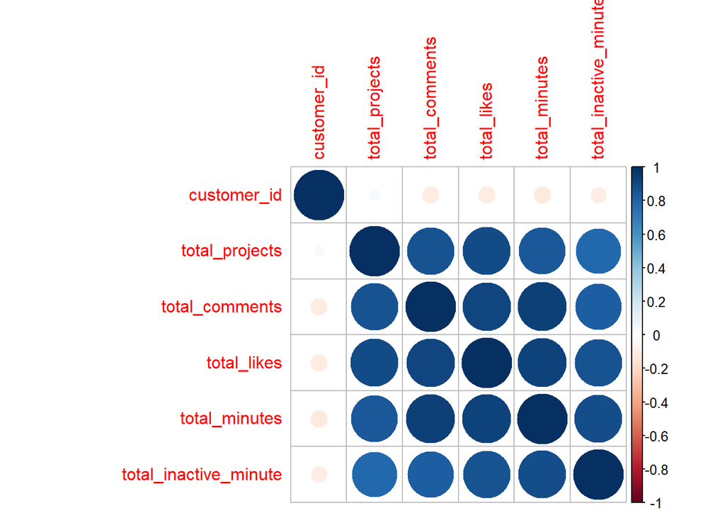

```r
top_users_corr <- showwcase_sessions %>%
select(session_projects_added,session_likes_given,session_comments_given,session_duration,customer_id,sessionminute,inactiveminute) %>%
  filter(!is.na(session_likes_given)) %>%
  group_by(customer_id) %>%
  summarise(total_projects = sum(session_projects_added), total_comments = sum(session_comments_given), total_likes = sum(session_likes_given), total_minutes = sum(sessionminute),total_inactive_minute = sum(inactiveminute)) %>%
  arrange(desc(total_minutes))

top_users_corr <- corrplot(cor(top_users_corr), method = "circle")
```

```r
summary(top_users_corr)
```

```
##   customer_id        total_projects    total_comments     total_likes
##  Min.   :-0.110770   Min.   :0.03958   Min.   :-0.1096   Min.   :-0.1079
##  1st Qu.:-0.109201   1st Qu.:0.80082   1st Qu.: 0.8383   1st Qu.: 0.8744
##  Median :-0.101258   Median :0.85352   Median : 0.8901   Median : 0.9054
##  Mean   : 0.102779   Mean   :0.73792   Mean   : 0.7392   Mean   : 0.7497
##  3rd Qu.: 0.006043   3rd Qu.:0.88664   3rd Qu.: 0.9302   3rd Qu.: 0.9246
##  Max.   : 1.000000   Max.   :1.00000   Max.   : 1.0000   Max.   : 1.0000
##  total_minutes     total_inactive_minute
##  Min.   :-0.1108   Min.   :-0.09458
##  1st Qu.: 0.8534   1st Qu.: 0.79744
##  Median : 0.9055   Median : 0.84880
##  Mean   : 0.7464   Mean   : 0.71221
##  3rd Qu.: 0.9329   3rd Qu.: 0.87965
##  Max.   : 1.0000   Max.   : 1.00000
```

#### Linear regression

```r
linear.model <- lm(showwcase_sessions$sessionminute ~ showwcase_sessions$session_projects_added*showwcase_sessions$session_likes_given*showwcase_sessions$session_comments_given, data = showwcase_sessions,family="binomial")
summary(linear.model)
```

```
##
## Call:
## lm(formula = showwcase_sessions$sessionminute ~ showwcase_sessions$session_projects_added *
##     showwcase_sessions$session_likes_given * showwcase_sessions$session_comments_given,
##     data = showwcase_sessions, family = "binomial")
##
## Residuals:
##      Min       1Q   Median       3Q      Max
## -20.5490  -9.4584  -0.5203   9.7653  20.5558
##
## Coefficients:
##                                                                                                                            Estimate
## (Intercept)                                                                                                                20.22922
## showwcase_sessions$session_projects_added                                                                                   0.64064
## showwcase_sessions$session_likes_given                                                                                      0.01922
## showwcase_sessions$session_comments_given                                                                                   0.08283
## showwcase_sessions$session_projects_added:showwcase_sessions$session_likes_given                                           -0.10894
## showwcase_sessions$session_projects_added:showwcase_sessions$session_comments_given                                        -0.26097
## showwcase_sessions$session_likes_given:showwcase_sessions$session_comments_given                                           -0.03001
## showwcase_sessions$session_projects_added:showwcase_sessions$session_likes_given:showwcase_sessions$session_comments_given  0.04450
##                                                                                                                            Std. Error
## (Intercept)                                                                                                                   2.26284
## showwcase_sessions$session_projects_added                                                                                     1.00443
## showwcase_sessions$session_likes_given                                                                                        0.18810
## showwcase_sessions$session_comments_given                                                                                     0.76061
## showwcase_sessions$session_projects_added:showwcase_sessions$session_likes_given                                              0.08601
## showwcase_sessions$session_projects_added:showwcase_sessions$session_comments_given                                           0.34835
## showwcase_sessions$session_likes_given:showwcase_sessions$session_comments_given                                              0.05955
## showwcase_sessions$session_projects_added:showwcase_sessions$session_likes_given:showwcase_sessions$session_comments_given    0.02650
##                                                                                                                            t value
## (Intercept)                                                                                                                  8.940
## showwcase_sessions$session_projects_added                                                                                    0.638
## showwcase_sessions$session_likes_given                                                                                       0.102
## showwcase_sessions$session_comments_given                                                                                    0.109
## showwcase_sessions$session_projects_added:showwcase_sessions$session_likes_given                                            -1.267
## showwcase_sessions$session_projects_added:showwcase_sessions$session_comments_given                                         -0.749
## showwcase_sessions$session_likes_given:showwcase_sessions$session_comments_given                                            -0.504
## showwcase_sessions$session_projects_added:showwcase_sessions$session_likes_given:showwcase_sessions$session_comments_given   1.680
##                                                                                                                            Pr(>|t|)
## (Intercept)                                                                                                                  <2e-16
```

[output cut: 8 more lines]

```
## (Intercept)                                                                                                                ***
## showwcase_sessions$session_projects_added
## showwcase_sessions$session_likes_given
## showwcase_sessions$session_comments_given
## showwcase_sessions$session_projects_added:showwcase_sessions$session_likes_given
## showwcase_sessions$session_projects_added:showwcase_sessions$session_comments_given
## showwcase_sessions$session_likes_given:showwcase_sessions$session_comments_given
## showwcase_sessions$session_projects_added:showwcase_sessions$session_likes_given:showwcase_sessions$session_comments_given .
## ---
## Signif. codes:  0 '***' 0.001 '**' 0.01 '*' 0.05 '.' 0.1 ' ' 1
##
## Residual standard error: 11.46 on 291 degrees of freedom
##   (1 observation deleted due to missingness)
## Multiple R-squared:  0.02086,    Adjusted R-squared:  -0.002692
## F-statistic: 0.8857 on 7 and 291 DF,  p-value: 0.5181
```

#### How is session duration dependent on the features

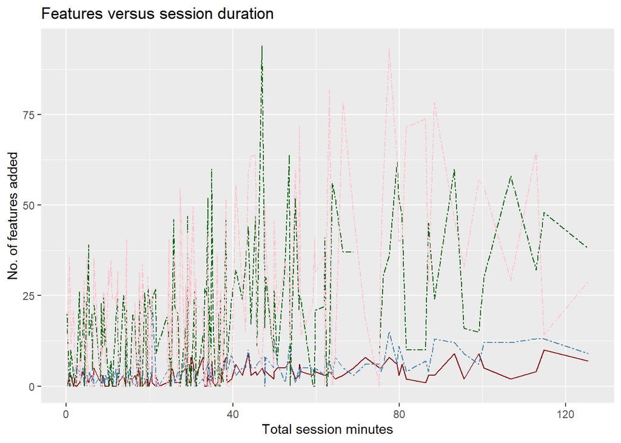

```r
ggplot(top_users, aes(x=top_users$total_minutes)) +
  geom_line(aes(y = top_users$total_projects), color = "darkred") +
  geom_line(aes(y = top_users$total_comments), color="steelblue", linetype="twodash") +

  geom_line(aes(y = top_users$total_likes), color="darkgreen", linetype="twodash") +

  geom_line(aes(y = top_users$total_inactive_minute), color="pink", linetype="twodash") + xlab("Total session minutes") + ylab("No. of features added") + ggtitle("Features versus session duration")
```

```r
library(tidyr)
gather_data <- top_users %>%
  select(total_projects, total_comments, total_likes,total_minutes) %>%
  gather(key = "variable", value = "value")
head(gather_data)
```

```
## # A tibble: 6 x 2
##   variable    value
##   <chr>       <dbl>
## 1 customer_id 40235
## 2 customer_id 87265
## 3 customer_id 29375
## 4 customer_id 23404
## 5 customer_id 23404
## 6 customer_id 87323
```